# Housing Subsidy

Anushka Samant

2023-10-10

```r
knitr::opts_chunk$set(echo = TRUE, warning = FALSE, message = FALSE, fig.align = 'left', cache = TRUE)

library(tidyverse)
library(kableExtra)
library(caret)
library(knitr)
library(pscl)
library(plotROC)
library(pROC)
library(lubridate)
library(pbkrtest)
library(lme4)
library(Matrix)
library(sjPlot)
#conflicts_prefer(dplyr::filter)

# data directory
source("https://raw.githubusercontent.com/urbanSpatial/Public-Policy-Analytics-Landing/master/functions.r")

root.dir = "https://raw.githubusercontent.com/urbanSpatial/Public-Policy-Analytics-Landing/master/DATA/"
housingsub <- read.csv(file.path(root.dir,"/Chapter6/housingSubsidy.csv"))

palette5 <- c("#440154","#3b528b","#21918c","#5ec962","#fde725")
palette4 <- c("#3b528b","#21918c","#5ec962","#fde725")
palette2 <- c("#3b528b","#5ec962")
```

# Motivation

The Department of Housing and Community Development in Emil City wants to improve their outreach strategy for a home repair tax credit program by using data-driven approaches to identify eligible homeowners, predict their likelihood of participating in a home repair tax credit program, and assess the cost-effectiveness of their outreach efforts. The ultimate aim is to increase the number of participants while reducing the money spent on marketing.

### Goals:

- **Increase Credit Uptake:** They want more eligible homeowners to take advantage of the home repair tax credit program. In other words, they aim to boost the number of people who use this benefit.
- **Decrease Marketing Expenditure:** They want to reduce the amount of money spent on marketing efforts. This implies that they want to make their outreach more efficient and cost-effective.

### Methodology:

- **Build a Classification Model:** This model will use a sample of data from previous outreach campaigns to predict whether a homeowner is likely to enter the tax credit program or not. It will sort homeowners into two categories: those likely to participate and those unlikely to participate.
- **Cost/Benefit Analysis:** This involves evaluating the financial costs associated with their outreach efforts (marketing and other resources) against the benefits gained by having more homeowners enter the program. The goal is to determine the effectiveness of the outreach and to allocate the limited resources more strategically.

# Data Exploration

### Key Variables

**Inflation Rate** (`inflation_rate`): When the US inflation rate is high, the likelihood of the outcome being “no” is notable. This suggests a negative correlation between a high inflation rate and program participation.

**Number of Previous Contacts** (`previous`): When the number of times a person was previously contacted (previous) is high, the likelihood of the outcome being “yes” is more prominent. This implies a positive correlation between a higher number of previous contacts and a greater chance of program participation.

**Unemployment Rate on the Day of Contact** (`unemploy_rate`): When the rate of unemployment on the day of contact is low (or even negative), the likelihood of the outcome being “yes” is significant. This indicates that a lower unemployment rate is associated with a higher likelihood of program participation.

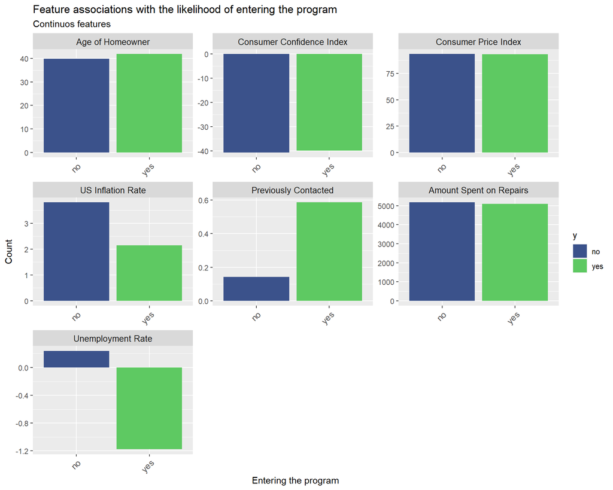

```r
housingsub %>%
  dplyr::select(y, age, previous, unemploy_rate, cons.price.idx, cons.conf.idx, inflation_rate, spent_on_repairs) %>%
  gather(Variable, value, -y) %>%
  ggplot(aes(y, value, fill = y)) +
    geom_bar(position = "dodge", stat = "summary", fun = "mean") +
    facet_wrap(~Variable, scales = "free", labeller = labeller(Variable = c(
      y = "Positive Outcome",
      age = "Age of Homeowner",
      previous = "Previously Contacted",
      unemploy_rate = "Unemployment Rate",
      cons.price.idx = "Consumer Price Index",
      cons.conf.idx = "Consumer Confidence Index",
      inflation_rate = "US Inflation Rate",
      spent_on_repairs = "Amount Spent on Repairs"
    ))) +
    scale_fill_manual(values = palette2) +
    labs(x = "Entering the program", y = "Count",
         title = "Feature associations with the likelihood of entering the program",
         subtitle = "Continuos features") +
    theme(axis.text.x = element_text(angle = 45, hjust = 1, size = 10),  # Adjust text size
          strip.text = element_text(size = 10))
```

**Contact** (`contact`):The “cellular” contact method has a higher count for “yes” outcomes compared to “telephone,” which suggests it could be a key variable.

**Education** (`education`): Different education levels have varying counts for “yes” outcomes, indicating possible importance.

**Job** (`job`): Job categories such as “student” and “retired” show variations in counts for “yes” outcomes.

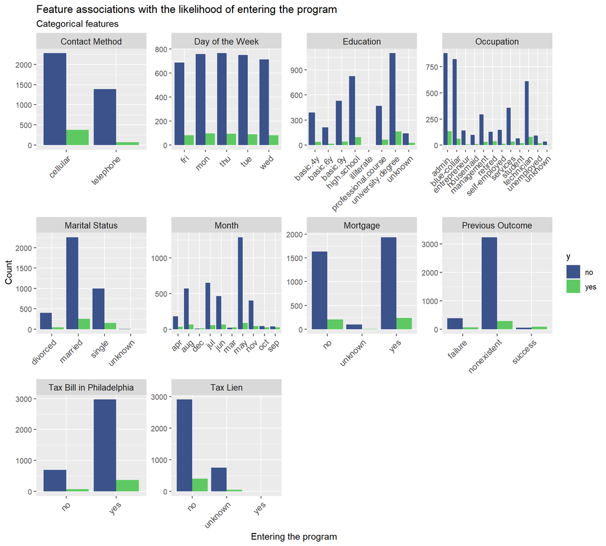

```r
housingsub %>%
  dplyr::select(y, taxbill_in_phl, contact, job, marital, education, taxLien, mortgage, month, day_of_week, poutcome) %>%
  gather(Variable, value, -y) %>%
  count(Variable, value, y) %>%
  ggplot(., aes(value, n, fill = y)) +
    geom_bar(position = "dodge", stat = "identity") +
    facet_wrap(~Variable, scales = "free", labeller = labeller(Variable = c(
      y = "Positive Outcome",
      taxbill_in_phl = "Tax Bill in Philadelphia",
      contact = "Contact Method",
      job = "Occupation",
      marital = "Marital Status",
      education = "Education",
      taxLien = "Tax Lien",
      mortgage = "Mortgage",
      month = "Month",
      day_of_week = "Day of the Week",
      poutcome = "Previous Outcome"
    ))) +
    scale_fill_manual(values = palette2) +
    labs(x = "Entering the program", y = "Count",
         title = "Feature associations with the likelihood of entering the program",
         subtitle = "Categorical features") +
    theme(axis.text.x = element_text(angle = 45, hjust = 1, size = 10),
          strip.text = element_text(size = 10))
```

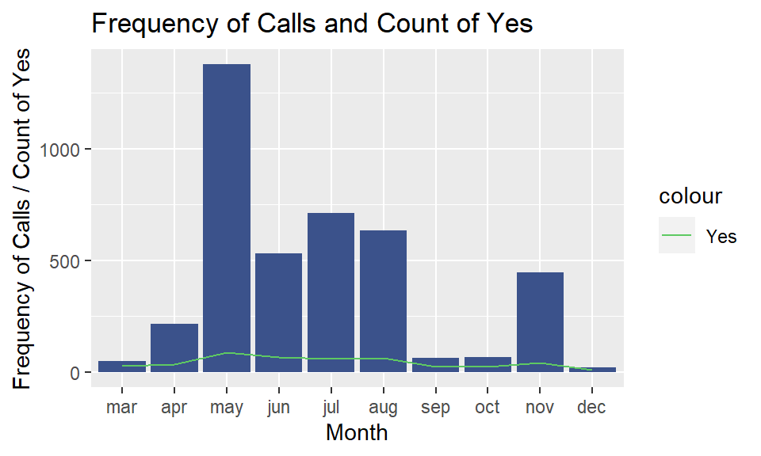

```r
# Define the correct order of months
month_order <- c("mar", "apr", "may", "jun", "jul", "aug", "sep", "oct", "nov", "dec")

# Calculate call frequency by month
call_counts <- housingsub %>%
  group_by(month) %>%
  summarise(call_frequency = n()) %>%
  mutate(month = factor(month, levels = month_order))

# Calculate the count of 'yes' by month
yes_counts <- housingsub %>%
  group_by(month) %>%
  summarise(Yes = sum(y == "yes")) %>%
  mutate(month = factor(month, levels = month_order))

combined_plot <- ggplot() +
  geom_bar(data = call_counts, aes(x = month, y = call_frequency), stat = "identity", fill = "#3b528b") +
  geom_line(data = yes_counts, aes(x = month, y = Yes, color = "Yes", group = 1)) +  # Specify group = 1
  scale_color_manual(values = c("Yes" = "#5ec962")) +
  labs(x = "Month", y = "Frequency of Calls / Count of Yes", title = "Frequency of Calls and Count of Yes")

# Display the combined plot
print(combined_plot)
```

# Modeling

In a logistic regression model, we’re trying to predict a binary outcome, like whether the homeowner will take the **subsidy (1) or not (0**). The model calculates coefficients for independent variables, which represent the change in the probability of the outcome based on changes in those variables.

We partition our data into a **65/35 split for training and testing**, it means that we use 65% of the data to train the model and 35% to test its performance. By using a 65/35 split instead of a balanced 50/50 split, we ensure that the model has a more appropriate balance of examples for each outcome class. This can help the model perform better because it’s exposed to more examples of the majority class (no) and can still learn from the minority class (yes) as well.

### Kitchen Sink Model

The **McFadden’s number for the kitchen sink is 0.2450601**, meaning that this model explains about 24.5% of the variance in the model.

```r
set.seed(34)
trainIndex <- createDataPartition(housingsub$y, p = .65,
                                  list = FALSE,
                                  times = 1)
subsidyTrain <- housingsub[ trainIndex,]
subsidyTest  <- housingsub[-trainIndex,]

subsidyModel <- glm(y_numeric ~ .,
                  data=subsidyTrain %>%
                  dplyr::select(-y, -X),
                  family="binomial" (link="logit"))

#summary(subsidyModel)
pR2(subsidyModel)
```

```
## fitting null model for pseudo-r2
```

```
##          llh      llhNull           G2     McFadden         r2ML         r2CU
## -699.7319118 -926.8710680  454.2783123    0.2450601    0.1559724    0.3123180
```

### Feature Engineered Model

In the feature engineering process, changes were made to the dataset with the aim of potentially improving the model’s performance. The following variables were transformed based on the results of the Data Exploration.

**Month**: Grouped `months` into “*low freq*” (April, March, September, October, November, December) and “*high freq*” (May, June, July, August) based on their occurrence. This grouping helps capture potential seasonality in the data, which may be relevant for the model’s predictions.

**Pdays**: Redefined the `pdays` variable to categorize it into “recent” for values 0-6, “1-2 weeks” for values 7-14, and “more than 2 weeks” for values 15-21. The value 999 was categorized as “NA.”

After these transformations, I split the data into training and testing sets and built a **logistic regression model** (`glm`) to predict the target variable `y_numeric` using all the engineered features and assessed its performance.

The **McFadden’s number for the kitchen sink is 0.2215975,** meaning that this model explains about 22.1% of the variance in the model. This means that our model is not improving as we expected it to.

```r
# histogram(housingsub$pdays)
# housingsub$campaign <- as.numeric(housingsub$campaign)
# histogram(housingsub$campaign)
# summary(housingsub$campaign)
#unique(housingsub$job)

# try re-categorize
engineered_subsidy <-
  housingsub %>%
  mutate(education,
         education = case_when(education == "basic.4y" ~ "elem",
                               education == "basic.6y" ~ "elem",
                               education == "basic.9y" ~ "high",
                               education == "high.school" ~ "high",
                               education == "professional.course" ~ "advanced",
                               education == "university.degree" ~ "advanced",
                               education == "illiterate"  ~ "basic",
                               education == "unknown" ~ "basic")) %>%
# mutate(campaign, campaign = if_else(campaign == "1", "1", "other")) %>%
  mutate(job = if_else(job %in% c("retired", "student"), job, "working")) %>%
  mutate(month = case_when(
      month %in% c("apr", "mar", "sep", "oct", "nov", "dec") ~ "low freq",
      month %in% c("may", "jun", "jul", "aug") ~ "high freq"))%>%
  mutate(pdays,
        pdays = case_when(pdays == "0"  ~ "recent",
                          pdays == "1" ~ "recent",
                          pdays == "2" ~ "recent",
                          pdays == "3" ~ "recent",
                          pdays == "4" ~ "recent",
                          pdays == "5" ~ "recent",
                          pdays == "6" ~ "recent",
                          pdays == "7" ~ "1-2 weeks",
                          pdays == "9"  ~ "1-2 weeks",
                          pdays == "10"  ~ "1-2 weeks",
                          pdays == "11"  ~ "1-2 weeks",
                          pdays == "12"  ~ "1-2 weeks",
                          pdays == "13"  ~ "1-2 weeks",
                          pdays == "14"  ~ "1-2 weeks",
                          pdays == "15"  ~ "more than 2 weeks",
                          pdays == "16" ~ "more than 2 weeks",
                          pdays == "17" ~ "more than 2 weeks",
                          pdays == "18" ~ "more than 2 weeks",
                          pdays == "19"~ "more than 2 weeks",
                          pdays == "20" ~ "more than 2 weeks",
                          pdays == "21" ~ "more than 2 weeks",
                          pdays == "999" ~ "NA")) %>%
 # mutate()
   dplyr::select(-taxbill_in_phl, -inflation_rate, -taxLien)

engineered_subsidyTrain <- engineered_subsidy[ trainIndex,]
engineered_subsidyTest  <- engineered_subsidy[-trainIndex,]

engineered_subsidyModel <- glm(y_numeric ~ .,
                  data=engineered_subsidyTrain %>%
                  dplyr::select(-y, -X),
                  family="binomial" (link="logit"))

#summary(engineered_subsidyModel)
#pR2(engineered_subsidyModel)
#pROC::auc(testProbs$Outcome, testProbs$Probs)
```

```r
# initial_model <- glm(y_numeric ~ .,
#                      data = engineered_subsidyTrain %>% dplyr::select(-y, -X),
#                      family = "binomial" (link = "logit"))
#
# final_model <- step(initial_model, direction = "backward")
#
# # Summary of the final model
# summary(final_model)
#
# # Calculate pseudo-R-squared for the final model
# pR2(final_model)
```

# Model Comparison

Both models provide insights into the variables associated with credit uptake and marketing expenditure. They both have moderate fits. While the variables’ significance varies, the choice of `contact` method consistently stands out as having an impact. The engineered model shows the influence of economic indicators on credit uptake and marketing expenditure.

```r
#summary(subsidyModel)
#summary(engineered_subsidyModel)

tab_model(subsidyModel, engineered_subsidyModel, transform = NULL, auto.label = FALSE,
          dv.labels = c("Kitchen Sink", "Engineered"),  show.est = TRUE, show.stat = TRUE, string.pred = "Coeffcient",
  string.ci = "Conf. Int (95%)",
  string.p = "P-Value")
```

|  | Kitchen Sink |  |  |  | Engineered |  |  |  |
| --- | --- | --- | --- | --- | --- | --- | --- | --- |
| Coeffcient | Log-Odds | Conf. Int (95%) | Statistic | P-Value | Log-Odds | Conf. Int (95%) | Statistic | P-Value |
| (Intercept) | -129.12 | -377.18 – 120.00 | -1.02 | 0.307 | -170.35 | -262.86 – -77.31 | -3.60 | **<0.001** |
| age | 0.02 | -0.00 – 0.03 | 1.74 | 0.082 | 0.02 | 0.00 – 0.03 | 2.00 | **0.046** |
| jobblue-collar | 0.06 | -0.49 – 0.61 | 0.22 | 0.822 |  |  |  |  |
| jobentrepreneur | -0.07 | -1.10 – 0.79 | -0.15 | 0.880 |  |  |  |  |
| jobhousemaid | 0.06 | -1.07 – 1.03 | 0.12 | 0.904 |  |  |  |  |
| jobmanagement | -0.20 | -0.83 – 0.39 | -0.64 | 0.522 |  |  |  |  |
| jobretired | -0.29 | -1.07 – 0.47 | -0.73 | 0.466 |  |  |  |  |
| jobself-employed | -0.62 | -1.56 – 0.20 | -1.40 | 0.162 |  |  |  |  |
| jobservices | -0.05 | -0.63 – 0.52 | -0.16 | 0.877 |  |  |  |  |
| jobstudent | 0.04 | -0.85 – 0.89 | 0.10 | 0.921 | 0.32 | -0.78 – 1.40 | 0.58 | 0.563 |
| jobtechnician | 0.10 | -0.40 – 0.59 | 0.39 | 0.697 |  |  |  |  |
| jobunemployed | 0.50 | -0.29 – 1.23 | 1.29 | 0.197 |  |  |  |  |
| jobunknown | -0.60 | -2.63 – 0.92 | -0.69 | 0.491 |  |  |  |  |
| maritalmarried | 0.30 | -0.21 – 0.85 | 1.12 | 0.263 | 0.29 | -0.20 – 0.83 | 1.12 | 0.264 |
| maritalsingle | 0.32 | -0.27 – 0.93 | 1.03 | 0.304 | 0.36 | -0.21 – 0.95 | 1.21 | 0.227 |
| maritalunknown | -10.84 | NA – 28.90 | -0.03 | 0.977 | -11.21 | NA – 28.68 | -0.03 | 0.977 |
| educationbasic.6y | 0.05 | -0.85 – 0.88 | 0.11 | 0.912 |  |  |  |  |
| educationbasic.9y | 0.25 | -0.39 – 0.90 | 0.76 | 0.448 |  |  |  |  |
| educationhigh.school | 0.31 | -0.30 – 0.95 | 0.98 | 0.325 |  |  |  |  |
| educationilliterate | -12.72 | NA – 166.93 | -0.01 | 0.989 |  |  |  |  |
| educationprofessional.course | 0.23 | -0.48 – 0.94 | 0.63 | 0.527 |  |  |  |  |
| educationuniversity.degree | 0.21 | -0.42 – 0.87 | 0.65 | 0.516 |  |  |  |  |
| educationunknown | 0.07 | -0.85 – 0.95 | 0.16 | 0.875 |  |  |  |  |
| taxLienunknown | 0.24 | -0.19 – 0.65 | 1.13 | 0.257 |  |  |  |  |
| mortgageunknown | -0.50 | -1.72 – 0.54 | -0.87 | 0.383 | -0.47 | -1.57 – 0.45 | -0.92 | 0.356 |
| mortgageyes | -0.31 | -0.60 – -0.02 | -2.07 | **0.038** | -0.27 | -0.55 – 0.02 | -1.83 | 0.068 |
| taxbill_in_phlyes | 0.07 | -0.31 – 0.47 | 0.34 | 0.732 |  |  |  |  |
| contacttelephone | -1.06 | -1.68 – -0.48 | -3.46 | **0.001** | -1.07 | -1.52 – -0.63 | -4.72 | **<0.001** |
| monthaug | 0.26 | -0.66 – 1.19 | 0.55 | 0.580 |  |  |  |  |
| monthdec | 1.15 | -0.32 – 2.63 | 1.53 | 0.126 |  |  |  |  |
| monthjul | 0.19 | -0.60 – 1.00 | 0.47 | 0.636 |  |  |  |  |
| monthjun | 0.61 | -0.31 – 1.56 | 1.28 | 0.200 |  |  |  |  |
| monthmar | 2.06 | 0.96 – 3.17 | 3.66 | **<0.001** |  |  |  |  |
| monthmay | -0.14 | -0.81 – 0.56 | -0.41 | 0.680 |  |  |  |  |
| monthnov | -0.26 | -1.17 – 0.67 | -0.55 | 0.586 |  |  |  |  |
| monthoct | 0.28 | -0.83 – 1.39 | 0.49 | 0.626 |  |  |  |  |
| monthsep | 0.50 | -0.76 – 1.77 | 0.78 | 0.434 |  |  |  |  |
| day_of_weekmon | -0.24 | -0.70 – 0.21 | -1.06 | 0.287 | -0.29 | -0.73 – 0.15 | -1.28 | 0.201 |
| day_of_weekthu | -0.13 | -0.58 – 0.32 | -0.56 | 0.572 | -0.20 | -0.64 – 0.24 | -0.89 | 0.376 |
| day_of_weektue | -0.15 | -0.61 – 0.31 | -0.62 | 0.532 | -0.13 | -0.58 – 0.32 | -0.56 | 0.574 |
| day_of_weekwed | 0.11 | -0.34 – 0.56 | 0.47 | 0.642 | 0.02 | -0.42 – 0.46 | 0.10 | 0.922 |
| campaign | -0.09 | -0.18 – -0.01 | -1.95 | 0.052 | -0.08 | -0.17 – 0.00 | -1.78 | 0.075 |
| pdays | -0.00 | -0.00 – 0.00 | -0.95 | 0.344 |  |  |  |  |
| previous | 0.09 | -0.26 – 0.47 | 0.51 | 0.610 | 0.08 | -0.27 – 0.46 | 0.43 | 0.668 |
| poutcomenonexistent | 0.50 | -0.12 – 1.16 | 1.55 | 0.120 | 0.51 | -0.09 – 1.15 | 1.63 | 0.103 |
| poutcomesuccess | 1.25 | -0.18 – 2.74 | 1.71 | 0.087 | 0.97 | -0.49 – 2.49 | 1.30 | 0.192 |
| unemploy_rate | -0.81 | -1.75 – 0.14 | -1.68 | 0.093 | -0.92 | -1.34 – -0.49 | -4.22 | **<0.001** |
| cons.price.idx | 1.32 | -0.32 – 2.96 | 1.58 | 0.114 | 1.65 | 0.97 – 2.34 | 4.75 | **<0.001** |
| cons.conf.idx | 0.04 | -0.01 – 0.10 | 1.52 | 0.128 | 0.06 | 0.03 – 0.09 | 3.96 | **<0.001** |
| inflation_rate | 0.06 | -0.84 – 0.96 | 0.13 | 0.898 |  |  |  |  |
| spent_on_repairs | 0.00 | -0.02 – 0.02 | 0.08 | 0.934 | 0.00 | -0.00 – 0.01 | 0.95 | 0.342 |
| jobworking |  |  |  |  | 0.20 | -0.48 – 0.91 | 0.56 | 0.575 |
| educationbasic |  |  |  |  | -0.23 | -1.03 – 0.48 | -0.60 | 0.546 |
| educationelem |  |  |  |  | -0.16 | -0.63 – 0.29 | -0.69 | 0.489 |
| educationhigh |  |  |  |  | 0.02 | -0.29 – 0.34 | 0.15 | 0.879 |
| monthlow freq |  |  |  |  | 0.11 | -0.22 – 0.44 | 0.66 | 0.507 |
| pdaysmore than 2 weeks |  |  |  |  | -1.18 | -3.58 – 1.22 | -1.01 | 0.313 |
| pdaysNA |  |  |  |  | -1.03 | -2.62 – 0.58 | -1.27 | 0.203 |
| pdaysrecent |  |  |  |  | -0.04 | -1.20 – 1.05 | -0.07 | 0.941 |
| Observations | 2679 |  |  |  | 2679 |  |  |  |
| R<sup>2</sup> Tjur | 0.253 |  |  |  | 0.230 |  |  |  |

# Cross-Validations: ROC, Sensitivity, Specificity

In both models;

ROC: Both models exhibit similar ROC values, indicating that they have good discrimination ability in distinguishing between participants and non-participants.

Sensitivity: The “Kitchen Sink” model has slightly higher sensitivity, suggesting it performs slightly better in identifying participants. However, the “Engineered” model still maintains a reasonable sensitivity.

Comparing the models, the “Engineered” model appears to be lightly more suitable for the Department’s goal of decreasing marketing expenditure while still maintaining a good ROC. It achieves a marginally higher specificity, which helps in targeting marketing efforts more efficiently. However, it’s important to consider the specific cost-benefit analysis and financial goals of the outreach efforts to make an informed decision about model selection.

### Kitchen Sink

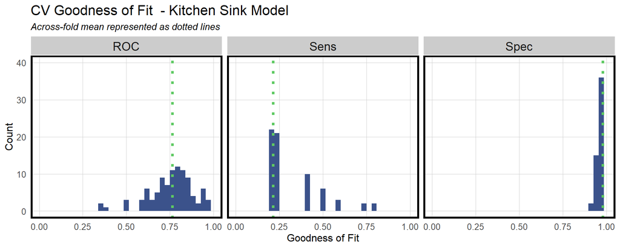

```r
ctrl <- trainControl(method = "cv", number = 100, classProbs=TRUE, summaryFunction=twoClassSummary)

cvFit <- train(y ~ ., data = housingsub %>%
                 dplyr::select(-y_numeric, -X) %>%
                 dplyr::mutate(y = ifelse(y == "no", "yes", "no")),
                 method="glm", family="binomial",
                 metric="ROC", trControl = ctrl)

dplyr::select(cvFit$resample, -Resample) %>%
  gather(metric, value) %>%
  left_join(gather(cvFit$results[2:4], metric, mean)) %>%
  ggplot(aes(value)) +
    geom_histogram(bins=35, fill = "#3b528b") +
    facet_wrap(~metric) +
    geom_vline(aes(xintercept = mean), colour = "#5ec962", linetype = 3, size = 1.5) +
    scale_x_continuous(limits = c(0, 1)) +
    labs(x="Goodness of Fit", y="Count", title="CV Goodness of Fit  - Kitchen Sink Model",
         subtitle = "Across-fold mean represented as dotted lines") +
    ylim(0, 40) +
    plotTheme()
```

```r
# Calculate summary statistics for each metric
cv_results <- cvFit$resample %>%
  dplyr::select(-Resample) %>%
  gather(metric, value) %>%
  left_join(gather(cvFit$results[2:4], metric, mean))

# Print the summary statistics
summary_stats <- cv_results %>%
  group_by(metric) %>%
  summarise(
    Mean = mean(value),
    Median = median(value),
    Min = min(value),
    Max = max(value)
  )
```

### Engineered Model

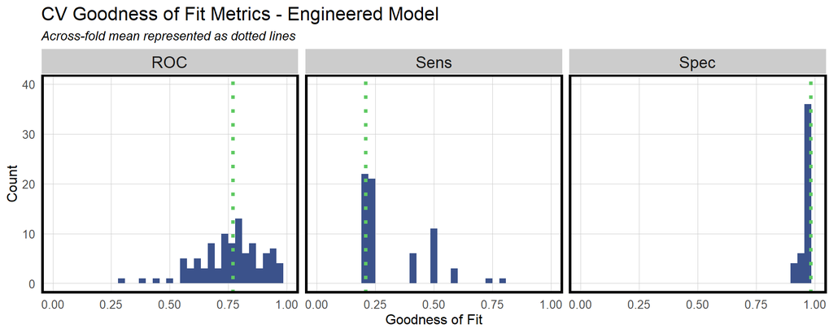

```r
engineered_cvFit <- train(y ~ ., data = engineered_subsidy %>%
                  dplyr::select(-y_numeric, -X) %>%
                 dplyr::mutate(y = ifelse(y == "no", "yes", "no")),
                method="glm", family="binomial",
                metric="ROC", trControl = ctrl)

dplyr::select(engineered_cvFit$resample, -Resample) %>%
  gather(metric, value) %>%
  left_join(gather(engineered_cvFit$results[2:4], metric, mean)) %>%
  ggplot(aes(value)) +
    geom_histogram(bins=35, fill = "#3b528b") +
    facet_wrap(~metric) +
    geom_vline(aes(xintercept = mean), colour = "#5ec962", linetype = 3, size = 1.5) +
    scale_x_continuous(limits = c(0, 1)) +
    labs(x="Goodness of Fit", y="Count", title="CV Goodness of Fit Metrics - Engineered Model",
         subtitle = "Across-fold mean represented as dotted lines") +
    ylim(0, 40) +
    plotTheme()
```

```r
# Calculate summary statistics for each metric
cv_results_eng <- engineered_cvFit$resample %>%
  dplyr::select(-Resample) %>%
  gather(metric, value) %>%
  left_join(gather(engineered_cvFit$results[2:4], metric, mean))

# Print the summary statistics
summary_stats_eng <- cv_results_eng %>%
  group_by(metric) %>%
  summarise(
    Mean = mean(value),
    Median = median(value),
    Min = min(value),
    Max = max(value)
  )

print(summary_stats)
```

```
## # A tibble: 3 × 5
##   metric  Mean Median   Min   Max
##   <chr>  <dbl>  <dbl> <dbl> <dbl>
## 1 ROC    0.765  0.781 0.362 0.995
## 2 Sens   0.216  0.2   0     0.8
## 3 Spec   0.980  0.973 0.919 1
```

```r
print(summary_stats_eng)
```

```
## # A tibble: 3 × 5
##   metric  Mean Median   Min   Max
##   <chr>  <dbl>  <dbl> <dbl> <dbl>
## 1 ROC    0.770  0.784 0.289   1
## 2 Sens   0.209  0.2   0       0.8
## 3 Spec   0.984  1     0.917   1
```

# ROC: Area Under Curve

The AUC (Area Under the Curve) quantifies the model’s ability to distinguish between the two classes, typically the “positive” and “negative” classes. In our model the AUC is 0.761 which indicates that the model is better than random chance. It means that, on average, the model is able to correctly rank a randomly chosen positive instance higher than a randomly chosen negative instance in about 76.1% of cases.

The closer the AUC value is to 1, the better the model’s discriminative ability. An AUC of 0.761 suggests a moderate level of discrimination. While not perfect, it indicates that the model has some capability to distinguish between the two classes.

```r
testProbs <- data.frame(Outcome = as.factor(engineered_subsidyTest$y_numeric),
                        Probs = predict(engineered_subsidyModel, engineered_subsidyTest %>% dplyr::select(-y, -X), type= "response"))
testProbs <-
  testProbs %>%
  mutate(predOutcome  = as.factor(ifelse(testProbs$Probs > 0.5 , 1, 0)))
  caret::confusionMatrix(testProbs$predOutcome, testProbs$Outcome, positive = "1")
```

```
## Confusion Matrix and Statistics
##
##           Reference
## Prediction    0    1
##          0 1266  137
##          1   17   20
##
##                Accuracy : 0.8931
##                  95% CI : (0.8759, 0.9086)
##     No Information Rate : 0.891
##     P-Value [Acc > NIR] : 0.4204
##
##                   Kappa : 0.1717
##
##  Mcnemar's Test P-Value : <2e-16
##
##             Sensitivity : 0.12739
##             Specificity : 0.98675
##          Pos Pred Value : 0.54054
##          Neg Pred Value : 0.90235
##              Prevalence : 0.10903
##          Detection Rate : 0.01389
##    Detection Prevalence : 0.02569
##       Balanced Accuracy : 0.55707
##
##        'Positive' Class : 1
##
```

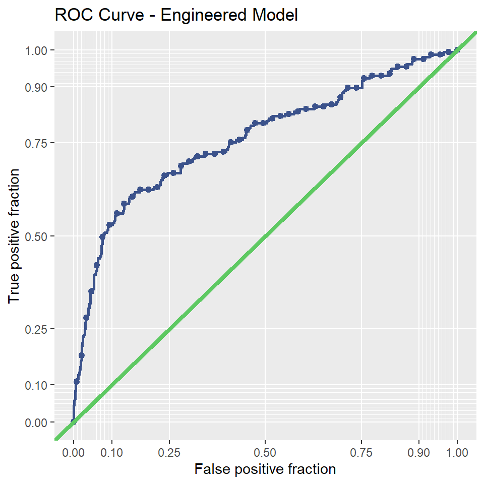

```r
ggplot(testProbs, aes(d = as.numeric(testProbs$Outcome), m = Probs)) +
  geom_roc(n.cuts = 50, labels = FALSE, colour = "#3b528b") +
  style_roc(theme = theme_grey) +
  geom_abline(slope = 1, intercept = 0, size = 1.5, color = "#5ec962") +
  labs(title = "ROC Curve - Engineered Model")
```

```r
pROC::auc(testProbs$Outcome, testProbs$Probs)
```

```
## Area under the curve: 0.7614
```

# Cost/Benefit Analysis

The cost-benefit analysis is a detailed breakdown of the financial implications of different outcomes in the context of a logistic model that predicts homeowner enrollment in a subsidy program. The analysis primarily focuses on the financial implications of true positives, true negatives, false positives, and false negatives.

1. **True Positives**: These are the cases where the model correctly predicted that a property owner would enroll in the subsidy program.
   - Revenue: $248,000
   - For these homeowners, the model successfully predicted their enrollment, and marketing resources were allocated. The net benefit was calculated by considering that 25% of homeowners who took the credit generated a net benefit of $12,400 per homeowner, accounting for the costs of marketing resources and the credit itself.
2. **True Negatives**: These are cases where the model correctly predicted that a homeowner would not enroll, and no marketing resources were allocated.
   - Revenue: $0
   - In these cases, the model correctly predicted that the homeowner would not take the credit, and no marketing expenses were incurred.
3. **False Positives**: These are cases where the model incorrectly predicted that a homeowner would take the credit, and marketing resources were allocated.
   - Revenue: -$48,450
   - In these cases, the model incorrectly predicted that homeowners would take the credit, leading to the allocation of marketing resources. However, no credit was allocated, resulting in a cost of $2,850 per homeowner (which includes staff and resources). This cost was incurred, but no revenue was generated.
4. **False Negatives**: These are cases where the model predicted that a homeowner would not take the credit, but they did.
   - Revenue: $0
   - These homeowners took the credit for reasons unrelated to the marketing campaign, and the analysis assumes that the cost/benefit of this is $0.

```r
cost_benefit_table <-
   testProbs %>%
      count(predOutcome, Outcome) %>%
      summarize(True_Negative = sum(n[predOutcome==0 & Outcome==0]),
                True_Positive = sum(n[predOutcome==1 & Outcome==1]),
                False_Negative = sum(n[predOutcome==0 & Outcome==1]),
                False_Positive = sum(n[predOutcome==1 & Outcome==0])) %>%
       gather(Variable, Count) %>%
       mutate(Revenue =
               case_when(Variable == "True_Negative"  ~ Count * 0,
                         Variable == "True_Positive"  ~ (12400 * Count),
                         Variable == "False_Negative" ~ 0 * Count,
                         Variable == "False_Positive" ~ (-2850) * Count)) %>%
    bind_cols(data.frame(Description = c(
              "We predicted correctly homeowner would not take the credit, no marketing resources were allocated.",
              "We predicted correctly homeowner would enter credit program; allocated the marketing resource.",
              "We predicted that a homeowner would not take the credit but they did.",
              "We predicted incorrectly homeowner would take the credit; allocated marketing resources.")))

kable(cost_benefit_table,
       caption = "Cost/Benefit Table") %>% kable_styling()
```

Cost/Benefit Table

| Variable | Count | Revenue | Description |
| --- | --- | --- | --- |
| True_Negative | 1266 | 0 | We predicted correctly homeowner would not take the credit, no marketing resources were allocated. |
| True_Positive | 20 | 248000 | We predicted correctly homeowner would enter credit program; allocated the marketing resource. |
| False_Negative | 137 | 0 | We predicted that a homeowner would not take the credit but they did. |
| False_Positive | 17 | -48450 | We predicted incorrectly homeowner would take the credit; allocated marketing resources. |

### Confusion Metric

The focus is on minimizing false positive expenditures to increase the efficacy of the subsidy program. The dollars spent on marketing represent a significant cost, and reducing false positives can reallocate resources toward subsidies for property owners. The analysis demonstrates the financial implications of different prediction outcomes based on the threshold chosen for the logistic model. In this specific analysis, a threshold of 0.5 was used.

The overall goal is to choose a threshold that maximizes the social benefit while minimizing marketing expenses. The analysis provides a quantitative understanding of the trade-offs involved in allocating resources for marketing and subsidies based on the model’s predictions. By choosing the right threshold, the Department can aim to maximize its social impact while managing costs effectively.

Here, we find that our **optimal threshold is 0.18.**

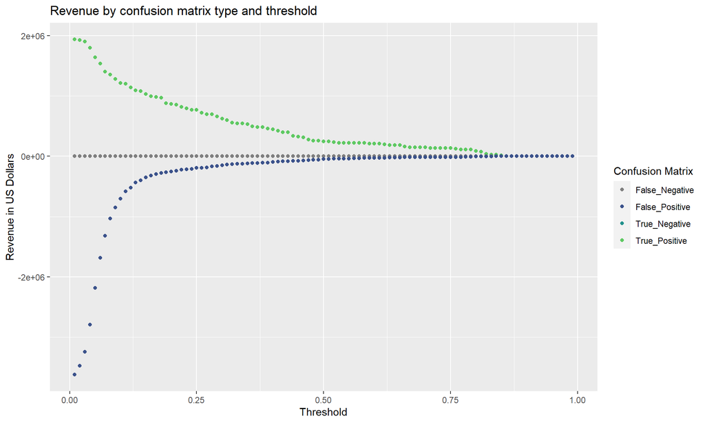

```r
iterateThresholds <- function(data) {
  x = .01
  all_prediction <- data.frame()
  while (x <= 1) {

  this_prediction <-
      testProbs %>%
      mutate(predOutcome = ifelse(Probs > x, 1, 0)) %>%
      count(predOutcome, Outcome) %>%
      summarize(True_Negative = sum(n[predOutcome==0 & Outcome==0]),
                True_Positive = sum(n[predOutcome==1 & Outcome==1]),
                False_Negative = sum(n[predOutcome==0 & Outcome==1]),
                False_Positive = sum(n[predOutcome==1 & Outcome==0])) %>%
     gather(Variable, Count) %>%
   mutate(Revenue =
               ifelse(Variable == "True_Negative", Count * 0,
               ifelse(Variable == "True_Positive", 12400 * Count,
               ifelse(Variable == "False_Negative", 0 * Count,
               ifelse(Variable == "False_Positive", (-2850) * Count, 0)))),
            Threshold = x)

  all_prediction <- rbind(all_prediction, this_prediction)
  x <- x + .01
  }
return(all_prediction)
}

whichThreshold <- iterateThresholds(testProbs2)

whichThreshold_revenue <-
whichThreshold %>%
    group_by(Threshold) %>%
    summarize(Revenue = sum(Revenue))

#confusion matrix
whichThreshold %>%
  ggplot(.,aes(Threshold, Revenue, colour = Variable)) +
  geom_point() +
  scale_colour_manual(values = palette4[c(5, 1:3)]) +
  labs(title = "Revenue by confusion matrix type and threshold",
       y = "Revenue in US Dollars") +
  guides(colour=guide_legend(title = "Confusion Matrix"))
```

### Total Revenue and Total Count of Credits as Functions of Threshold

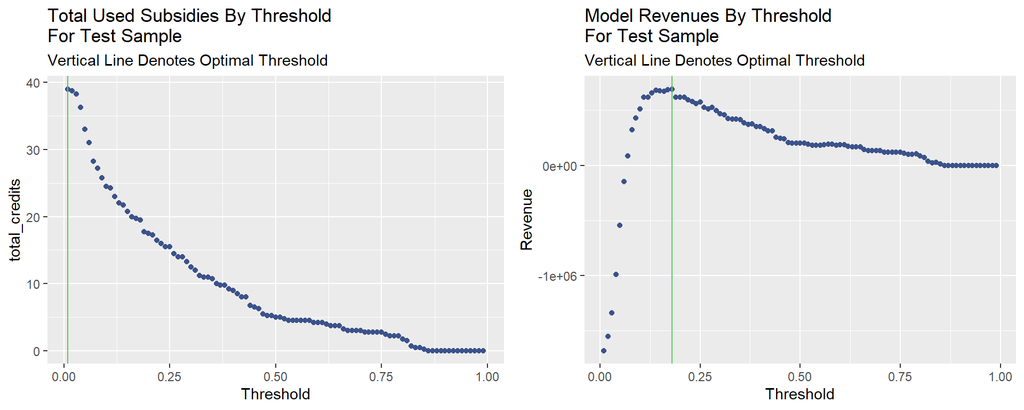

```r
library(gridExtra)

# Create the data and plots
whichThreshold_count <-
  whichThreshold %>%
  group_by(Threshold) %>%
  filter(., Variable == "True_Positive") %>%
  summarize(total_credits = (sum(Count)) * 0.25)

countplot <- ggplot(whichThreshold_count) +
  geom_point(aes(x = Threshold, y = total_credits), color = "#3b528b") +
  geom_vline(xintercept = pull(arrange(whichThreshold_count, -total_credits)[1, 1]), color = "#5ec962") +  # Set vline color
  labs(title = "Total Used Subsidies By Threshold \nFor Test Sample",
       subtitle = "Vertical Line Denotes Optimal Threshold")

whichThreshold_revenue <-
  whichThreshold %>%
  group_by(Threshold) %>%
  summarize(Revenue = sum(Revenue))

revenueplot <- ggplot(whichThreshold_revenue) +
  geom_point(aes(x = Threshold, y = Revenue), color = "#3b528b") +
  geom_vline(xintercept = pull(arrange(whichThreshold_revenue, -Revenue)[1, 1]), color = "#5ec962") +  # Set vline color
  labs(title = "Model Revenues By Threshold \nFor Test Sample",
       subtitle = "Vertical Line Denotes Optimal Threshold")

# Arrange the plots
grid.arrange(countplot, revenueplot, ncol = 2)
```

### Optimal Threshold vs 50% Threshold

1. **Threshold 0.18**:
   - **Total Revenue**: $690,750
   - **Interpretation**: When using a threshold of 0.18 for the logistic model, the total revenue generated is $690,750. This means that the model predicts a certain number of homeowners to enroll in the subsidy program based on this threshold. The revenue includes both correctly predicted enrollments (true positives) and any associated costs or benefits related to marketing and subsidies. This level of revenue is achieved by making predictions that include a relatively broader range of potential enrollees, which may lead to more enrollments.
2. **Threshold 0.5**:
   - **Total Revenue**: $199,550
   - **Interpretation**: When using a threshold of 0.5 for the logistic model, the total revenue generated is $199,550. This threshold represents a different level of model stringency, where only predictions with higher confidence are considered. Consequently, the model is less likely to predict enrollments, which reduces the total revenue. While this threshold may reduce the revenue, it could also lead to cost savings by reducing false positive predictions and the associated marketing costs.

The choice of threshold is a trade-off between maximizing revenue and minimizing costs. A lower threshold captures more potential enrollees but may also lead to more false positives, increasing marketing costs. In contrast, a higher threshold reduces false positives but may miss out on some potential enrollees, potentially reducing revenue. The optimal threshold depends on the organization’s goals and the balance they aim to strike between revenue generation and cost control.

```r
whichThreshold_revenue %>%
  filter(Threshold %in% c("0.18", "0.5")) %>%
  kable(caption = "Total Revenue and Total Count of Credits for Optimal Threshold and 0.5 Threshold") %>%
 kable_styling()
```

Total Revenue and Total Count of Credits for Optimal Threshold and 0.5 Threshold

| Threshold | Revenue |
| --- | --- |
| 0.18 | 690750 |
| 0.50 | 199550 |

# Conclusion

In considering the goodness of fit of the model and its potential impact on revenue, it is evident that the imbalanced dataset poses a significant challenge. The current model may be heavily skewed towards homeowners who did not enter the program, as indicated by the low sensitivity.

A balanced sample that adequately represents both classes could lead to more accurate model results. While the model’s specificity is high, its ability to identify homeowners who would enroll in the subsidy program requires more work.

**Recommendation:**

In its current state, I would not recommend putting this model into production. The imbalanced dataset and the low sensitivity of the model pose substantial limitations. To consider production, the following steps are essential:

1. **Improved Sampling Techniques:** Utilize better sampling techniques, rather than relying on random samples of previous campaigns, to ensure a balanced representation of both classes in the dataset.
2. **Model Enhancement:** Refine the model to improve its ability to identify positive cases, focusing on a more targeted audience using classification techniques.
3. **Enhanced Marketing Efforts:** Allocate additional resources to working sessions for program application processes, catering to eligible homeowners to ensure that marketing materials yield a better response rate.

Balancing the dataset and refining the model are critical steps for making this predictive tool a valuable asset for increasing homeowner enrollment in the subsidy program. Without these enhancements, the model may not reach its full potential in a production environment.

# References

The data for this lab has been adopted from [Moro & Rita (2014)](https://urbanspatial.github.io/PublicPolicyAnalytics/people-based-ml-models.html#fn48).

Public Policy Analytics: Code & Context for Data Science in Government https://urbanspatial.github.io/PublicPolicyAnalytics/index.html